# STAA57 W20 Final Project Report

Group #17L Girvan Tse, Edmond Lee, Brandom Lam

## Introduction

### Description of Report

This report wants to glean insights into the emergency shelter situation in Toronto using data. At its core we will be asking two main questions: “How operational are emergency shelters?” and ‘What influences emergency shelter usage?’. We happen to pick this topic because when looking into 211 Caller Data we found that emergency shelters contained a lot of calls and unsuccessful resolutions. It however wasn’t the most numerous in terms of number of calls nor contain the most unsuccessful resolutions out of all the categories so we thought this would make a good middle ground topic that isn’t discussed as much.

### What is an emergency shelter?

An emergency shelter is defined as a facility that’s used to house residences temporarily for emergency situations. Common inhabitants of shelters include both individuals and families. The reason of use may vary, but common rationale for using the shelters usually involve fleeing a dangerous situation such as: natural/ man-made disaster, domestic/sexual violence and abuse. In emergency situations such as extreme cold or rain, some of these shelters operate as warming centres for the homeless should they have the capacity to do so. The facilities provide various accommodations for residents including beds, meals, showers, counselling, and referral to: legal, health, and employment services.

### Who is the demographic of an emergency shelter?

The demographic of the emergency shelters includes a wide range of people. These include both male/female adults/youth, and families of varying sizes. The shelters are usual portioned off by sector to accommodate the various residence. They have spaces that are for men, women, youth, co-ed, families, and those with more specific/ sensitive needs such as victims of abuse.

## Data

### 211 Caller Data

#### Usage

Geographical, Caller Reason, Caller demographic, and Caller Gender data for emergency shelters

#### Variables and Observations

Level3Name Category variable that helps us slice 211 caller data for emergency shelter  
Level4Name Category variable to help distinguish different reasons for calling in terms of emergency shelters  
PostalArea Postal Codes of Toronto  
DateOfCall Date of call  
NeedWasMet Boolean specifying if the needs of the caller were met  
Demographics of Inquirer Age Category Determines if caller is Youth, Adult, Order Adult, or Unknown  
Demographics of Gender Age Category Determines if caller is Male, Female, or Unknown

#### Bias

The PostalArea has a non-response bias. That is there is a large amount of calls that contain NULL in PostalArea

### Daily Shelter Occupancy

#### Link

https://open.toronto.ca/dataset/daily-shelter-occupancy/

#### Usage

Geographical Data on the location of shelters as well as occupancy to calculate demographics and usage

#### Variables and Observations

OCCUPANCY_DATE Date of shelter operation  
SHELTER_NAME Name of shelter  
SHELTER_ADDRESS Address of shelter  
SHELTER_POSTAL_CODE postal code of shelter  
SECTOR Categorisation variable for different parts of any shelter  
OCCUPANCY The count of occupants in any shelter sector  
CAPACITY The count of available spaces in any shelter

#### Bias

There is possible bias towards families since they wouldn’t be counted as a group, so a family group of 4 is not 1 entry but 4 in terms of the OCCUPANCY variable. Though it would still be hard to mangle the variable into a way that would could a single-family group since the number of members in a family can range from 2 to more.

### Toronto Postal Codes

#### Link

https://www.canadapost.ca/cpo/mc/personal/postalcode/fpc.jsf

#### Usage

Converting Postcodes to City of Toronto Boroughs

#### Variables and Observations

Postcode Postal Codes of Toronto  
Borough Boroughs of Toronto  
Neighbourhoods Neighbourhoods of Toronto

## Main Analysis

Here we’ll break up the main questions into several sub questions. Namely the following two big questions.  
Also we’ll start to use abbreviations to make the report more succinct  
ES = Emergency Shelter  
CD = 211 Caller Data (callerData)  
ESD = Emergency Shelter Data (shelterData)  
OC = Overcapacity  
OCR = Overcapacity Rate

How functional are ESs?  
1.0 What are the ES trends?  
1.0a Using CD  
1.0b Using ESD  
1.1 Are callers able to reach ESs?  
1.2 Which regions are ESs in high demand?  
1.0 will tell us if ESs capacity is rising or falling. This would hinder operation of course as being OC or max capacity will hurt the delivery of the ES service. 1.1 will tell us if ESs are able to receive callers via the 211 line. 1.2 will tell us which region ESs callers ask about the most.

What influences ES usage?  
2.1 Does borough influence number of calls in a day?  
2.2 Does sector of ES user influence OCR?  
2.3 Is ES usage seasonal (monthly) ?  
2.4 Can we classify shelters as OC based solely on their load?  
2.1, 2.2, 2.3 are each different metrics that could influence ES usage. 2.4 will tell us which shelters are at max usage in some sector based on usage.

### How functional are ESs?

#### 1.0 : What are the ES trends?

##### Method

For this topic we can look at both our data sets to see if we can find trends. We’ll use our CD see if the frequency of calls increases over time using different grouping views. Our grouping views will consist of daily, weekly, and monthly. The reason why we’ll exclude yearly is that the data abstraction will be too much to obtain any information from.

We’ll split the analysis into two sections, 1.0a and 1.0b for CD and ESD respectively. Doing this we can get two different measures on increasing emergency shelter usage. In 1.0a we’ll be observing if the trend for 211 calls increases or decreases over the years. In 1.0b we’ll observe two variables: overall load and OCR. Overall load will consist of the sum of all occupants over capacity to calculate how full a shelter is. OCR will consist of overall mean at which the shelters are at or over capacity.

##### 1.0a CD

Here we’ll perform a simple summation of the data to see how it trend weekly, this should give us a pretty granular but not too granular view.

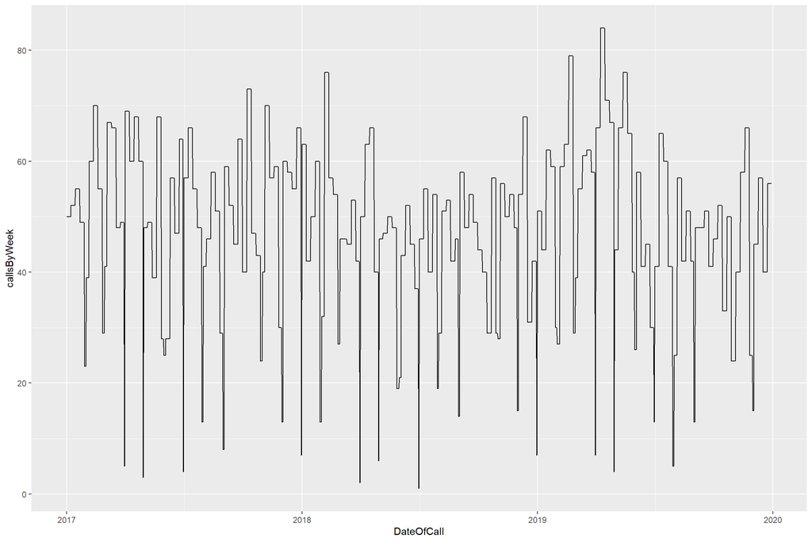

##### 1.0b ESD

Done similarly to the 1.0a, however this time we’ll measure both load (occupancy over capacity) and OCR (mean of sectors OC).

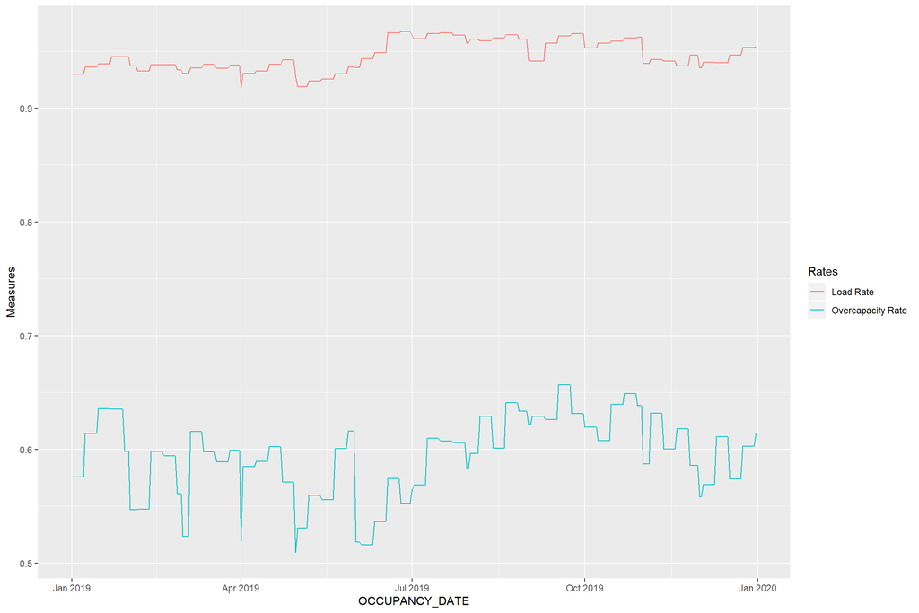

##### Conclusion

Here we should consider the bias in 1.0b that OCR is the mean of sectors that are OC in a shelter, but not all shelters contain the same number of sectors. This means we might see more variance in OCR. However looking at 1.0a and 1.0b we can conclude there is no trend. In both graphs we can see that the data trends towards a centre line (considering the bias for OCR).

#### 1.1 Is every caller able to reach a nearby ES?

##### Method

Here we’ll take the CD and do a check to see if it matches a postal code of any shelter, if it is then we can consider that the user is able to reach an ES (regardless of if it is full/OC or not)

##### Analysis

Here we’ll simply pull all FSA codes of shelters in Toronto and filter all FSA codes of callers not in the shelters FSA. If we find any calls that exist in FSA that aren’t in a shelters FSA we can summarise those.

| PostalArea | calls |
| --- | --- |
| M4J | 13 |
| M6N | 8 |
| M4L | 7 |
| M6R | 7 |
| M9C | 5 |
| M1J | 4 |
| M1N | 4 |
| M3N | 4 |
| M4A | 4 |
| M6S | 4 |

[output cut: 37 more lines]

Using the sum of callers without a shelter in their FSA we can get a proportion

```
## [1] 0.4127907
```

That is 41.28% of callers (with geographical data) do not have a shelter in their FSA

##### Conclusion

Here we should consider that there is a vocal minority in geographical data. Converting the postal codes to boroughs yields callers are mainly unable to reach shelters exactly in the East York region. Though considering the bias we cannot say that with certainty that most callers unable to reach shelters are in the EY region.

#### 1.2 Which regions are ESs in high demand?

##### Method

Here we can do an inner join on postal code; this will yield us the caller’s borough. After that we do a simple summarise on the data to yield the total number of calls over the years for ESs. We can take the highest number of calls as the most in-demand region for ESs

##### Analysis

We’ll retrieve CD with geographical data and join our callerData with postalBorough to get our borough data from the calls. Then perform a summation to get the number of calls by borough.

| Borough | Calls |
| --- | --- |
| Downtown Toronto | 193 |
| Scarborough | 112 |
| Etobicoke | 97 |
| North York | 93 |
| West Toronto | 74 |
| Central Toronto | 59 |
| York | 40 |
| East Toronto | 35 |
| East York | 24 |
| Queen's Park | 1 |

##### Conclusion

We consider that the dataset contains non-response bias. Following our method and considering the data we take the top regions as the most in-demand regions then we can see that lots of callers are from the DT, Scarborough, North York and Etobicoke boroughs.

### What influences ES usage?

#### 2.1: Does borough influence number of calls in a day?

##### Method

We can use an independence test to see if the number of calls in a day is influenced by the borough. Specifically this will tell us on any given day if borough influences how many calls are received. We are specifically testing if the number of calls vary from borough to borough, or if it is standard across all boroughs. The assumption that is standard means we are assuming the need for ESs is the same across all boroughs while the alternate proposes the opposite.

##### Analysis

Here we join ES with postalBorough to get boroughs. Summarising yields data we can perform an independence test on. We’ll test number of calls in a day and borough to see if they’re related.  
H0 : The borough and number of calls are not related  
Halt : The borough and number of calls are related  
We’ll work with a 95% confidence interval (and thus require p <= 0.05 to reject the null)

```
##
##  Approximative General Independence Test
##
## data:  Calls by
##   Borough (Central Toronto, Downtown Toronto, East Toronto, East York, Etobicoke, North York, Queen's Park, Scarborough, West Toronto, York)
## maxT = 6.67, p-value < 1e-04
## alternative hypothesis: two.sided
```

#### 2.2: Does sector of ES user influence OCR?

##### Method

Here we need to get the OCR of ESs, afterwards we’ll need to do an independence test to see if sectors and OCR are related. This specifically will point out if some sectors are often OC, more so than others.

##### Analysis

We can use shelter data like previously to get the OCR. The difference is now we’ll use that in tandem with the factor SECTOR and an independence test.  
H0 : All sectors are equally likely to have OC issues  
Halt : Some sectors are more often OC than others  
We’ll work with a 95% confidence interval (and thus require p <= 0.05 to reject the null)

```
##
##  Approximative General Independence Test
##
## data:  SECTOR by OC_RATE
## maxT = 33.866, p-value < 1e-04
## alternative hypothesis: two.sided
```

#### 2.3: Is ES usage seasonal (monthly) ?

##### Method

This question will help us determine if shelter usage is affected by the month.

##### Analysis

```
##
##  Approximative General Independence Test
##
## data:  MONTH by LOAD
## Z = 7.9429, p-value < 1e-04
## alternative hypothesis: two.sided
```

##### Conclusion

| MONTH | LOAD |
| --- | --- |
| 1 | 0.9381621 |
| 2 | 0.9360921 |
| 3 | 0.9357951 |
| 4 | 0.9350675 |
| 5 | 0.9261899 |
| 6 | 0.9538506 |
| 7 | 0.9637455 |
| 8 | 0.9613369 |
| 9 | 0.9557274 |
| 10 | 0.9580488 |

[output cut: 2 more lines]

It seems that June, July, August, September, and October have higher loads than the winter months. This goes against my intuition that cold weather would cause higher shelter load. Overall however we can see that the month does affect how much shelters are being used.

#### 2.4: Can we classify shelters as regularly OC based solely on their load?

##### Method

Here we will use threshold classification to find a classifer that will tell us if a shelter is OC based solely on its load. This is a useful metric because it’ll let us have a good metric for if a shelter should expand or not. I.e. if our classifer is the best at < 0.7 load we can recommend any shelter with an overall load <= 0.7 that they should expand their services.

##### Analysis

Here we’ll graph our shelter data to see what a good initial classifer would be. From the graph we can determine that 0.895 is a pretty good divide between OC and high load.

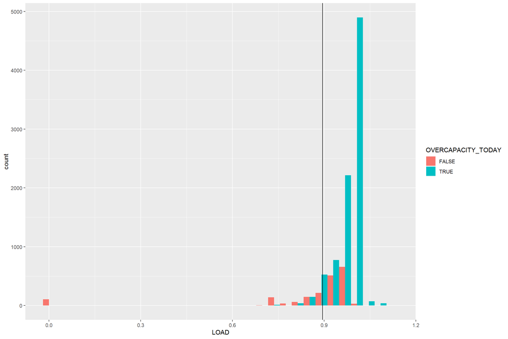

To confirm this we can make a crosstab with our data comparing our guess and the real state of the ESs

```
##         OC_REAL
## OC_GUESS  TRUE FALSE   Sum
##    TRUE   8180  1287  9467
##    FALSE   541   621  1162
##    Sum    8721  1908 10629
```

Doing a small calculation for accuracy yields

```
## [1] 0.8280177
```

Plotting a ROC curve shows that out our model is moderately accurate able to reach about at best a balanced 75% precision/75% recall

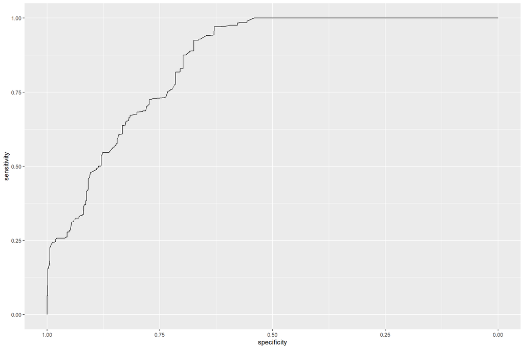

```
## Area under the curve: 0.8546
```

##### Conclusion

The classifer can’t achive above a 75% precision/75% recall. For this given context of ESs I would say this isn’t accurate enough. Since a shelter being OC can mean life or death for people using ESs.

## Summary

Here we’ll restate and answer all the questions using insight gleaned from the data. I’ll add a short answer to the subsections then answer the main question.

### How functional are ESs?

1.0 What are the ES trends? Stagnant  
1.0a Using CD  
1.0b Using ESD  
1.1 Are callers able to reach ESs? Yes considering bias, No without considering bias  
1.2 Which regions are ESs in high demand? Downtown Toronto

Using the subsections we can see that ESs in Toronto are functional. They serve their purpose well, but the stagnant trend of ESs is concerning. This means the usage of ESs may not be increasing but is also not decreasing as well, that is there is no action being taken to actively reduce the amount that ESs are being used. We can see that (vocal minority) callers aren’t able to shelters in their FSA (mainly East York) but they are a very small fraction of callers when compared to the most in demands areas (13~ vs 193~).

### What influences ES usage?

2.1 Does borough influence number of calls in a day? Yes  
2.2 Does sector of ES user influence OCR? Yes  
2.3 Is ES usage seasonal (monthly) ? Yes  
2.4 Can we classify shelters as regularly OC based solely on their load? No

## Appendix

### Footnote for Professor

Girvan Here  
I tried using ggmaps but found that in 2018 google changed the requirement to use the API to a private key from google cloud. If I wanted to put a ggmap into the report, I’d need to also publicly put in my private key for my google account in the R code to allow readers to run the report. Also tried using the maps and sp package but they have their own problems (maps is doesn’t contain up to date Canadian political borders; sp uses GADM which takes ages to render).

Also I tried using PCCF but found it was too detailed and unwieldly (it seems to be more compatible for SAS) for an FSA -> Borough conversion. I do understand however that PCCF is a more academic source (and frankly better than just pulling postal codes by hand.)